# Predicting Length of Stay for Patients

```python
# Importing libraries necessary for the modelling
import numpy as np
import pandas as pd

# Visualalization Libraries
import seaborn as sns
import matplotlib.pyplot as plt

# Modelling libraries

from sklearn.linear_model import LinearRegression
from sklearn.metrics import mean_squared_error,r2_score
from sklearn.model_selection import train_test_split
from sklearn.preprocessing import StandardScaler
```

#### Reading the Data

```python
data = pd.read_csv('HealthCareDataSet.csv')
data.drop(['Id'],axis=1,inplace = True)       # dropping ID column as no analysis is to be done on this feature
data.shape                                    # number of rows and columns in the dataset
```

```
(10999, 12)
```

## 1. Data Cleaning

#### 1.1 Handling Missing values

```python
data.isnull().sum()
```

```
LengthOfStay                 0
ReadmissionCount          5570
Gender                       0
FacilityId                   0
KidneyAilments           10999
HeartAilments            10999
PyschologicalAilments        0
SubstanceAbuseHistory      392
BMI                          2
ABG                          0
Pulse                        2
SecondaryDiagnosis         239
dtype: int64
```

```python
data.SubstanceAbuseHistory.value_counts()
```

```
SubstanceAbuseHistory
No         9080
Yes        1517
Some          3
Slight        3
Few           3
Unknown       1
Name: count, dtype: int64
```

- Will replace all missing values with 'unknown'
- Combine categories like some, slight and few to 'Yes'

```python
data['SubstanceAbuseHistory'].replace(to_replace=['Some','Slight','Few'],value='Yes',inplace=True)
```

```python
data.KidneyAilments.value_counts()
```

```
Series([], Name: count, dtype: int64)
```

```python
data.HeartAilments.value_counts()
```

```
Series([], Name: count, dtype: int64)
```

```python
data.ReadmissionCount.value_counts()
```

```
ReadmissionCount
1.0    2701
2.0    1422
3.0     736
4.0     380
5.0     190
Name: count, dtype: int64
```

```python
data.SecondaryDiagnosis.value_counts()
```

```
SecondaryDiagnosis
1.0     4196
2.0     2610
3.0     1568
4.0      946
5.0      545
6.0      363
7.0      221
8.0      133
0.0       81
9.0       59
10.0      38
Name: count, dtype: int64
```

```python
data.drop(['KidneyAilments','HeartAilments'],axis=1,inplace = True)            # Dropping these columns as all data points are null in this feature
data['SubstanceAbuseHistory'] = data['SubstanceAbuseHistory'].fillna('Unknown')     # replacing missing values with existing category - 'Unknown'
data['ReadmissionCount'] = data['ReadmissionCount'].fillna(1.0)             # filling up missing data in this column with the MODE
data['SecondaryDiagnosis'] = data['SecondaryDiagnosis'].fillna(1.0)             # filling up missing data in this column with the MODE
data.drop(['FacilityId'],axis=1,inplace=True)                          # This feature is the ID for every facility, does not provide any info
```

```python
data.isnull().sum()
```

```
LengthOfStay             0
ReadmissionCount         0
Gender                   0
PyschologicalAilments    0
SubstanceAbuseHistory    0
BMI                      2
ABG                      0
Pulse                    2
SecondaryDiagnosis       0
dtype: int64
```

```python
data.describe()
```

|  | LengthOfStay | ReadmissionCount | BMI | ABG | Pulse | SecondaryDiagnosis |
| --- | --- | --- | --- | --- | --- | --- |
| count | 10999.000000 | 10999.000000 | 10997.000000 | 10999.000000 | 10997.000000 | 10999.000000 |
| mean | 4.554232 | 1.435858 | 29.059925 | 142.644591 | 77.751023 | 2.415492 |
| std | 3.302963 | 0.891275 | 2.006137 | 30.329310 | 18.135555 | 1.772709 |
| min | 1.000000 | 1.000000 | 19.800000 | -1.010000 | 10.000000 | 0.000000 |
| 25% | 2.000000 | 1.000000 | 27.700000 | 123.000000 | 65.000000 | 1.000000 |
| 50% | 4.000000 | 1.000000 | 29.000000 | 143.000000 | 78.000000 | 2.000000 |
| 75% | 6.000000 | 1.000000 | 30.400000 | 163.000000 | 90.000000 | 3.000000 |
| max | 29.000000 | 5.000000 | 36.700000 | 253.000000 | 148.000000 | 10.000000 |

```python
print('BMI Skewness: ',data.BMI.skew())
print('ABG Skewness: ',data.ABG.skew())
print('Pulse Skewness: ',data.Pulse.skew())
```

```
BMI Skewness:  0.009490073032178605
ABG Skewness:  -0.16247525191238377
Pulse Skewness:  0.019439814221374058
```

- Numerical Features like Length of Stay, BMI, ABG and Pulse have mean very close to the median. This means that the data has very less skewness and for missing data imputation we can use either mean or median.
- Readmission count and Secondary Diagnosis and actually categorical data that we will be changing the type of later on
- As the skewness for the numerical features are very less we can assume that the data is normal with mean and median having similar values

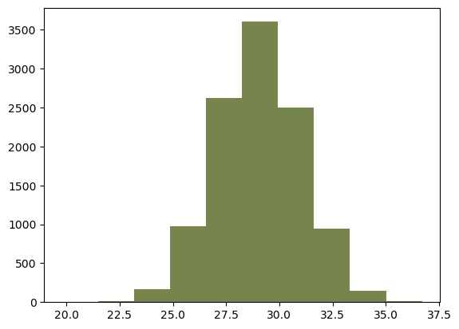

```python
plt.hist(data['BMI'],color='#76854E')
plt.show()
```

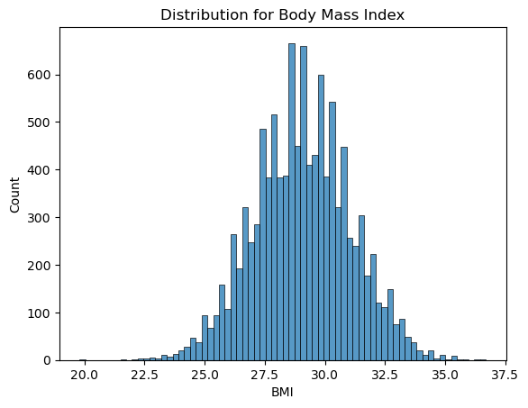

```python
sns.histplot(data['BMI'])
plt.title('Distribution for Body Mass Index')
plt.show()
```

```python
# From the chart above we can see that the data is normal. With mean alomost equal to the median
data['BMI'] = data['BMI'].fillna(data['BMI'].median())               # filling up missing data points in this numerical feature with the median
```

From the distribution plot we see that the data is mostly normal. So, we replace missing values with either mean or median

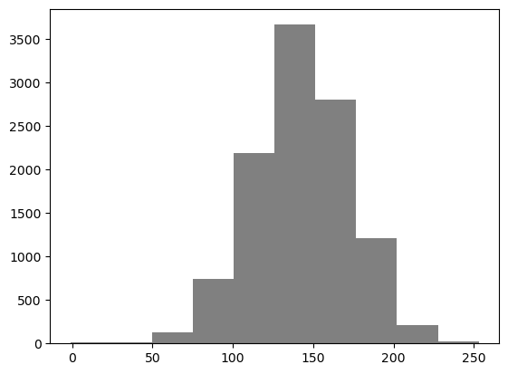

```python
plt.hist(data['ABG'],color='grey')
plt.show()
```

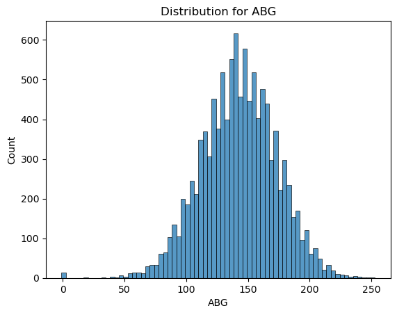

```python
sns.histplot(data['ABG'])
plt.title('Distribution for ABG')
plt.show()
```

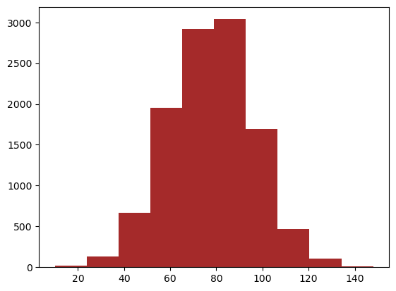

```python
plt.hist(data['Pulse'],color='brown')
plt.show()
```

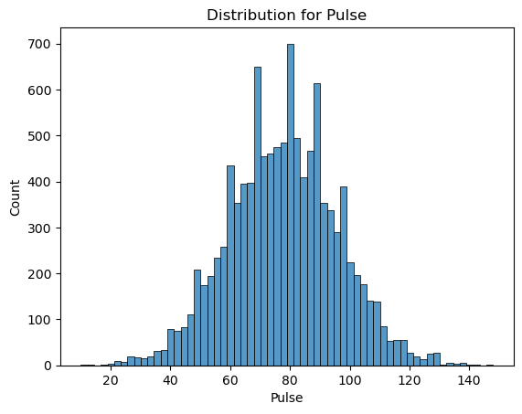

```python
sns.histplot(data['Pulse'])
plt.title('Distribution for Pulse')
plt.show()
```

```python
# From the chart above we can see that the data is normal. With mean alomost equal to the median
data['Pulse'] = data['Pulse'].fillna(data['Pulse'].median())               # filling up missing data points in this numerical feature with the median
```

In this distribution plot as well we see that the data is mostly normal. So, we replace missing values with either mean or median

```python
data.isnull().sum()           # all missing values have been handled
```

```
LengthOfStay             0
ReadmissionCount         0
Gender                   0
PyschologicalAilments    0
SubstanceAbuseHistory    0
BMI                      0
ABG                      0
Pulse                    0
SecondaryDiagnosis       0
dtype: int64
```